# Lab07_SVM_Banking

COMPX310-2025 Lab 7  
Support Vector Machines  
Banking Marketing Campaign Analysis

[figure not shown]

### Lab Overview

**Total Points: 3**

In this lab, you will apply **Support Vector Machines (SVM)** for classification and **Support Vector Regression (SVR)** to analyze banking data.

### Learning Objectives

- Understand and apply Support Vector Machines for classification
- Implement Support Vector Regression for numerical prediction
- Evaluate model performance using appropriate metrics

[figure not shown]

## 1. Business Understanding

### Background

StirBank has been running marketing campaigns to encourage customers to set up regular savings deposits. However, calling many customers is costly and risks annoying people. The bank needs a data-driven approach to identify which customers are most likely to respond positively.

### Problem Statement

**Part 1 - Classification Task:** Predict whether a customer will make a deposit (`made_deposit`) based on their characteristics and previous interactions.

**Part 2 - Regression Task:** Predict a customer's current balance based on their demographic and banking characteristics.

### Why Data Mining?

Data mining is suitable because:

- We have historical data with known outcomes
- The relationships between variables are complex and non-linear
- Manual rules would be difficult to create and maintain
- Automated prediction can save costs and improve targeting

### Key Terminology

- **Model**: A mathematical representation learned from data
- **Features/Variables**: Input attributes used for prediction
- **Target**: The variable we want to predict
- **SVM**: Support Vector Machine - finds optimal decision boundaries
- **Kernel**: Function that transforms data into higher dimensions
- **Hyperparameters**: Parameters that control the learning process (C, gamma, kernel type)

## 2. Import Required Libraries

Import all necessary Python libraries for this lab. You will need:

- Data manipulation libraries (pandas, numpy)
- Visualization libraries (matplotlib, seaborn)
- Preprocessing tools from scikit-learn (StandardScaler, LabelEncoder, train_test_split)
- SVM models from scikit-learn (SVC for classification, SVR for regression)
- Model selection tools (GridSearchCV for hyperparameter tuning)
- Evaluation metrics for both classification and regression tasks
- Configure any necessary settings (warnings, plot styles)

```python
import numpy as np
import pandas
import matplotlib.pyplot as plt
import seaborn as sns

from sklearn.preprocessing import StandardScaler, LabelEncoder
from sklearn.model_selection import train_test_split, GridSearchCV
from sklearn.svm import SVC, SVR
from sklearn.pipeline import Pipeline
from sklearn.compose import ColumnTransformer
from sklearn.metrics import accuracy_score, classification_report, confusion_matrix, roc_curve, roc_auc_score, r2_score, mean_absolute_error, mean_squared_error
```

## 3. Data Understanding

### Load and Explore the Dataset

Load the 'bank-tr.csv' file and perform initial exploration:

- Read the CSV file into a pandas DataFrame
- Display the shape of the dataset (should be 8000 rows × 20 columns)
- Show the first few rows to understand the data structure
- Display information about column data types and any missing values

```python
df = pandas.read_csv("bank-tr.csv")

print("Shape of data: ")
print(df.shape)

# print("First five rows: ")
# print(df.head())

print("Feature names: ")
print(df.columns)

print("Missing values: ")
print(df.isnull().sum())
```

```
Shape of data:
(8000, 20)
Feature names:
Index(['accountID', 'town', 'country', 'age', 'job', 'marital', 'education',
       'defaulted?', 'current_balance', 'housing', 'has_loan', 'last_contact',
       'cc_tr', 'last_contact_day', 'last_contact_month', 'campaign',
       'days_since_last_contact', 'previous', 'poutcome', 'made_deposit'],
      dtype='object')
Missing values:
accountID                  0
town                       0
country                    0
age                        0
job                        0
marital                    0
education                  0
defaulted?                 0
current_balance            0
housing                    0
has_loan                   0
last_contact               0
cc_tr                      0
last_contact_day           0
last_contact_month         0
campaign                   0
days_since_last_contact    0
previous                   0
poutcome                   0
made_deposit               0
dtype: int64
```

### Data Dictionary

Review the variables in the dataset and fill type and Usefulness.

- Go through each column and classify it as **categorical** or **numerical**
- Mark it as **1 nominal, 2 ordinal, 3 continuous, or 4 discrete**
- Decide whether it is useful for prediction or should be dropped

| Variable | Description | Type | Usefulness |
| --- | --- | --- | --- |
| accountID | Unique customer identifier | 2 | N |
| town | Customer's town | 1 | Y |
| country | Customer's country | 1 | Y |
| age | Customer's age | 4 | Y |
| job | Type of job | 1 | Y |
| marital | Marital status | 4 | Y |
| education | Education level | 2 | Y |
| defaulted? | Has credit in default | 4 | Y |
| current_balance | Current account balance | 4 | Y |
| housing | Has housing loan | 4 | Y |
| has_loan | Has personal loan | 4 | Y |
| last_contact | Contact communication type | 1 | Y |
| cc_tr | Number of contacts in campaign | 4 | Y |
| last_contact_day | Day of last contact | 4 | N |
| last_contact_month | Month of last contact | 4 | Y |
| campaign | Number of contacts in this campaign | 4 | Y |
| days_since_last_contact | Days since previous campaign | 4 | Y |
| previous | Number of previous contacts | 4 | Y |
| poutcome | Outcome of previous campaign | 4 | Y |
| made_deposit | Did customer make deposit? (**TARGET VARIABLE**) | 4 | Y |

### Summary Statistics

Generate and display summary statistics:

- Use appropriate pandas methods to display summary statistics for numerical variables
- For categorical variables, display the unique values and their frequencies
- Check for any missing values in the dataset

```python
num_features = [c for c in df.columns if df[c].dtype != "O"]
cat_features = [c for c in df.columns if df[c].dtype == "O"]

print("Summary for numerical feature: ")
print(df[num_features].describe())

print("Unique values for categorical feature: ")
print(df[cat_features].value_counts())
```

```
Summary for numerical feature:
          accountID          age  current_balance        cc_tr  \
count  8.000000e+03  8000.000000      8000.000000  8000.000000
mean   5.540746e+07    41.211750      1516.520500     3.011250
std    2.596137e+07    11.972545      3168.517624     1.419903
min    1.000040e+07    18.000000     -3058.000000     1.000000
25%    3.305826e+07    32.000000       120.000000     2.000000
50%    5.558780e+07    39.000000       545.500000     3.000000
75%    7.769044e+07    49.000000      1694.000000     4.000000
max    9.999599e+07    93.000000     81204.000000     5.000000

       last_contact_day     campaign  days_since_last_contact     previous
count        8000.00000  8000.000000              8000.000000  8000.000000
mean           15.70875     2.497125                51.573375     0.840375
std             8.43299     2.770145               109.155207     2.371307
min             1.00000     1.000000                -1.000000     0.000000
25%             8.00000     1.000000                -1.000000     0.000000
50%            15.00000     2.000000                -1.000000     0.000000
75%            22.00000     3.000000                33.250000     1.000000
max            31.00000    63.000000               854.000000    58.000000
Unique values for categorical feature:
town        country  job          marital  education  defaulted?  housing  has_loan  last_contact  last_contact_month  poutcome  made_deposit
Birmingham  UK       blue-collar  married  secondary  no          yes      no        unknown       may                 unknown   no              7
London      UK       blue-collar  married  secondary  no          yes      no        unknown       may                 unknown   no              6
Glasgow     UK       management   married  tertiary   no          no       no        cellular      aug                 unknown   no              6
                                                                  yes      no        unknown       may                 unknown   no              5
Birmingham  UK       management   married  tertiary   no          yes      no        unknown       may                 unknown   no              5
                                                                                                                                                ..
Gillingham  UK       student      single   secondary  no          no       no        cellular      may                 failure   yes             1
                     services     single   secondary  no          yes      no        unknown       may                 unknown   yes             1
                                                                                     cellular      may                 unknown   yes             1
                                  married  secondary  no          yes      no        cellular      may                 unknown   yes             1
York        UK       unknown      married  unknown    no          no       no        cellular      aug                 unknown   yes             1
Name: count, Length: 7678, dtype: int64
```

### Target Variable Analysis

Analyze the distribution of the target variable 'made_deposit':

- Display value counts and percentages
- Create visualizations to show the distribution (bar chart and/or pie chart)
- Assess whether the classes are balanced or imbalanced
- Comment on what you observe about the class distribution

```
made_deposit
no     4172
yes    3828
Name: count, dtype: int64
0.5215
0.4785
```

[figure not shown]

```python
print(df["made_deposit"].value_counts())

print(df["made_deposit"].value_counts()[0] / df["made_deposit"].value_counts().sum())
print(df["made_deposit"].value_counts()[1] / df["made_deposit"].value_counts().sum())

sns.barplot(df["made_deposit"])
plt.title("Bar Chart for Target Feature")
plt.xlabel("Number")

# Balanced.
```

## 4. Data Preparation

### Step 4.1: Data Quality Assessment

Examine the data for quality issues:

- Check for any inconsistent values in categorical columns (e.g., different spellings or abbreviations)
- Look specifically at binary columns like 'housing', 'has_loan', and 'defaulted?' for any unexpected values
- Identify any typos or data entry errors that need correction
- Document any issues you find

### Step 4.2: Data Cleaning

Clean any data quality issues you identified:

- Create a copy of the dataframe for processing
- Fix any inconsistent values (e.g., standardize abbreviations)
- Document what changes you made and why
- Verify that the cleaning was successful by checking the unique values again

```python
df_copy = df.copy()
```

### Step 4.3: Visualize Distributions (Before Preprocessing)

Create histograms to visualize the distribution of key numerical variables:

- Select important numerical features (age, current_balance, campaign, days_since_last_contact, previous)
- Create histogram plots to understand their distributions
- Look for skewness, outliers, or unusual patterns
- These visualizations will help you understand if any transformations are needed

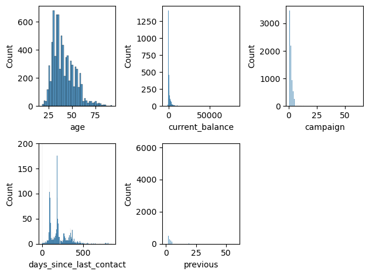

```python
ipt_num_features = ["age", "current_balance", "campaign", "days_sicne_last_contact", "previous"]

plt.subplot(2, 3, 1)
sns.histplot(df["age"])

plt.subplot(2, 3, 2)
sns.histplot(df["current_balance"])

plt.subplot(2, 3, 3)
sns.histplot(df["campaign"])

plt.subplot(2, 3, 4)
sns.histplot(df["days_since_last_contact"])
plt.ylim(0, 200)

plt.subplot(2, 3, 5)
sns.histplot(df["previous"])

plt.tight_layout()
```

### Step 4.4: Remove Irrelevant Features

Remove features that won't contribute to prediction:

- Drop the 'accountID' column (it's just an identifier with no predictive value)
- Drop the 'country' column (all values are the same - UK, so it provides no information)
- Consider whether to keep or drop 'town' (too many unique values may not be useful)
- Print the remaining columns to verify the changes

```python
df_copy.drop("accountID", axis=1, inplace=True)
df_copy.drop("country", axis=1, inplace=True)
df_copy.drop("town", axis=1, inplace=True)

print("Feature names after preprocessing: ")
print(df_copy.columns)
```

```
Feature names after preprocessing:
Index(['age', 'job', 'marital', 'education', 'defaulted?', 'current_balance',
       'housing', 'has_loan', 'last_contact', 'cc_tr', 'last_contact_day',
       'last_contact_month', 'campaign', 'days_since_last_contact', 'previous',
       'poutcome', 'made_deposit'],
      dtype='object')
```

### Step 4.5: Feature Engineering (Optional)

Create new features that might improve model performance:

- Consider creating a binary feature indicating whether the customer was contacted before
- Consider creating age groups from the continuous age variable
- Think about other features that might be useful based on domain knowledge
- Document any new features you create and your reasoning

## 5. Modeling - Part 1: SVM Classification

### Objective

Build a Support Vector Machine classifier to predict whether a customer will make a deposit.

### Step 5.1: Prepare Data for Classification

Separate features and target variable:

- Create X (features) by dropping the target column 'made_deposit' and any variables you won't use
- Create y (target) from the 'made_deposit' column
- Convert the target to binary format (1 for 'yes', 0 for 'no')
- Verify the shapes and distribution of your features and target

```python
X = df_copy.iloc[:, :-1]
y = df_copy.iloc[:, -1]

y = y.map({"yes": 1, "no": 0})

print(X.shape)
print(y.shape)
print(y.head())
```

```
(8000, 16)
(8000,)
0    1
1    1
2    1
3    0
4    1
Name: made_deposit, dtype: int64
```

### Step 5.2: Encode Categorical Variables

Convert categorical variables to numerical format:

- Identify which columns are categorical and which are numerical
- Use LabelEncoder to encode categorical variables into numerical values
- Store the encoders in a dictionary in case you need them later
- Verify that all columns are now numerical

```python
num_features = [c for c in X.columns if df[c].dtype != "O"]
cat_features = [c for c in X.columns if df[c].dtype == "O"]

X[num_features] = StandardScaler().fit_transform(X[num_features])

for col in cat_features:
    labelencoder = LabelEncoder()
    X[col] = labelencoder.fit_transform(X[col])

print("Shape of X after preprocessing: ")
print(X.shape)
```

```
Shape of X after preprocessing:
(8000, 16)
```

### Step 5.3: Split Data into Train, Validation, and Test Sets

Create three datasets for proper model evaluation:

- Split the data into 60% training, 20% validation, and 20% test
- First split 80-20 for (train+validation) and test
- Then split the 80% into 75-25 to get 60% train and 20% validation
- Use stratification to maintain class balance across splits
- Set random_state=42 for reproducibility
- Print the sizes of each set to verify the split

```python
X_plus, X_test, y_plus, y_test = train_test_split(X, y, random_state=6327, test_size=0.2, stratify=y)

X_training, X_val, y_training, y_val = train_test_split(X_plus, y_plus, random_state=6327, test_size=0.25, stratify=y_plus)

print("Shape of X_training: ")
print(X_training.shape)
print("Shape of X_val: ")
print(X_val.shape)
print("Shape of X_test: ")
print(X_test.shape)
```

```
Shape of X_training:
(4800, 16)
Shape of X_val:
(1600, 16)
Shape of X_test:
(1600, 16)
```

### Step 5.4: Feature Scaling

**⚠️ CRITICAL:** SVMs are very sensitive to feature scales. You must standardize features.

Apply StandardScaler to normalize features:

- Initialize a StandardScaler
- Fit the scaler on the training data ONLY
- Transform all three sets (train, validation, test) using the fitted scaler
- Never fit the scaler on validation or test data to avoid data leakage
- Verify that the scaled features have mean≈0 and std≈1

```python
stdscaler = StandardScaler()

X_train_scaled = stdscaler.fit_transform(X_training)

X_val_scaled = stdscaler.transform(X_val)
X_test_scaled = stdscaler.transform(X_test)

print("Mean of scaled features: ")
print(np.mean(X_train_scaled, axis=0))
print("Std of scaled features: ")
print(np.std(X_train_scaled, axis=0))
```

```
Mean of scaled features:
[ 4.07081776e-18  6.80936788e-17 -4.66293670e-17 -7.54951657e-17
 -4.21884749e-17  4.44089210e-18 -5.62512999e-17  2.48689958e-16
  7.84557604e-17 -4.07081776e-17  2.07241631e-17  1.37667655e-16
  6.06921920e-17  3.25665421e-17 -2.96059473e-18  2.96059473e-17]
Std of scaled features:
[1. 1. 1. 1. 1. 1. 1. 1. 1. 1. 1. 1. 1. 1. 1. 1.]
```

### Step 5.5: Build Baseline SVM Model

Create a simple baseline SVM model:

- Initialize an SVC (Support Vector Classifier) with default parameters
- Use the RBF kernel (this is the default)
- Train the model on the scaled training data
- Make predictions on the validation set
- Calculate and display the accuracy score
- Print a classification report showing precision, recall, and F1-score

```python
svc_1 = SVC()

svc_1.fit(X_train_scaled, y_training)

y_pred_val = svc_1.predict(X_val_scaled)

acc_score = accuracy_score(y_val, y_pred_val)
print("Accuracy score of validation set is: ")
print(acc_score)

print(classification_report(y_val, y_pred_val))
```

```
Accuracy score of validation set is:
0.70375
              precision    recall  f1-score   support

           0       0.69      0.78      0.73       835
           1       0.72      0.62      0.67       765

    accuracy                           0.70      1600
   macro avg       0.71      0.70      0.70      1600
weighted avg       0.71      0.70      0.70      1600
```

### Step 5.6: Hyperparameter Tuning

Use GridSearchCV to find the best hyperparameters:

- Define a parameter grid with different values for:
  - **C**: Regularization parameter (try 0.1, 1, 10, 100)
  - **gamma**: Kernel coefficient (try 'scale', 'auto', 0.001, 0.01, 0.1)
  - **kernel**: Kernel type (try 'rbf' and 'linear')
- Create a GridSearchCV object with 5-fold cross-validation
- Fit the grid search on the training data
- Display the best parameters found
- Display the best cross-validation score
- This process may take several minutes to complete

```python
parameter_grid = {"C": [0.1, 1, 10, 100], "gamma": ["scale", "auto", 0.001, 0.01, 0.1], "kernel": ["rbf", "linear"]}

gs = GridSearchCV(estimator=SVC(), cv=5, param_grid=parameter_grid, refit=True, n_jobs=-1)

gs.fit(X_train_scaled, y_training)

print("Best parameters: ")
print(gs.best_params_)
print("Best score:")
print(gs.best_score_)
```

```
Best parameters:
{'C': 1, 'gamma': 'auto', 'kernel': 'rbf'}
Best score:
0.678125
```

### Step 5.7: Analyze Grid Search Results

Examine the grid search results:

- Extract the cv_results_ from the grid search
- Create a DataFrame to view the results in a structured format
- Display the top 10 parameter combinations
- Note which parameters seem to work best
- Compare different kernels and their performance

```python
print("Results of gridsearchCV: ")
res_gs = pandas.DataFrame(gs.cv_results_)
# print(res_gs)

res_gs_sorted = res_gs.sort_values("rank_test_score")
print(res_gs_sorted.head(10))
```

```
Results of gridsearchCV:
    mean_fit_time  std_fit_time  mean_score_time  std_score_time param_C  \
12       0.723038      0.071731         0.303973        0.021843       1
18       0.783535      0.077796         0.328332        0.026340       1
10       0.750933      0.062260         0.318276        0.019144       1
26       0.814196      0.089104         0.322680        0.042593      10
8        0.694027      0.069800         0.329366        0.006356     0.1
0        0.679579      0.046020         0.323370        0.011370     0.1
2        0.704226      0.054116         0.569411        0.429331     0.1
34       0.869904      0.080393         0.303622        0.020167     100
36       1.384346      0.051223         0.287736        0.026541     100
16       0.733444      0.014100         0.342433        0.019729       1

   param_gamma param_kernel                                         params  \
12        auto          rbf     {'C': 1, 'gamma': 'auto', 'kernel': 'rbf'}
```

[output cut: 45 more lines]

### Step 5.8: Train Final SVM Model

Use the best model from grid search:

- Extract the best estimator from the grid search results
- Make predictions on the validation set
- Calculate accuracy and compare it to the baseline model
- Print a detailed classification report
- Note the improvement (if any) over the baseline

```python
y_pred_gs = gs.predict(X_val_scaled)

acc_score_gs = accuracy_score(y_val, y_pred_gs)
print("accuracy score of gsCV: ")
print(acc_score_gs)

print("classification report of gsCV: ")
print(classification_report(y_val, y_pred_gs))
```

```
accuracy score of gsCV:
0.70375
classification report of gsCV:
              precision    recall  f1-score   support

           0       0.69      0.78      0.73       835
           1       0.72      0.62      0.67       765

    accuracy                           0.70      1600
   macro avg       0.71      0.70      0.70      1600
weighted avg       0.71      0.70      0.70      1600
```

### Step 5.9: Final Evaluation on Test Set

Evaluate the final model on unseen test data:

- Use the best model to make predictions on the test set
- Calculate and display the test accuracy
- Generate a comprehensive classification report
- This is your final model performance - report these numbers

```python
y_pred_text = gs.predict(X_test_scaled)

print("Acccuracy of best model: ")
print(accuracy_score(y_test, y_pred_text))

print("classification report of best model: ")
print(classification_report(y_test, y_pred_text))
```

```
Acccuracy of best model:
0.69875
classification report of best model:
              precision    recall  f1-score   support

           0       0.69      0.76      0.72       834
           1       0.71      0.63      0.67       766

    accuracy                           0.70      1600
   macro avg       0.70      0.70      0.70      1600
weighted avg       0.70      0.70      0.70      1600
```

## 6. Evaluation - Classification

### Step 6.1: Confusion Matrix

Create and visualize a confusion matrix:

- Generate a confusion matrix comparing actual vs predicted values
- Visualize it using a heatmap with proper labels
- Extract the four values: True Negatives, False Positives, False Negatives, True Positives
- Interpret what each quadrant means:
  - True Negatives: Correctly predicted "No deposit"
  - False Positives: Predicted "Deposit" but actually "No" (Type I error)
  - False Negatives: Predicted "No" but actually "Deposit" (Type II error)
  - True Positives: Correctly predicted "Deposit"
- Discuss the business implications of each type of error

```
confusion matrix of best model:
[[635 199]
 [283 483]]
```

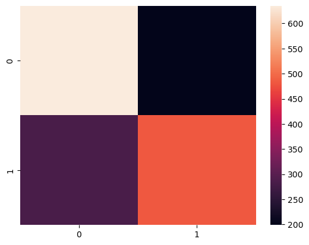

```python
confusion_m = confusion_matrix(y_test, y_pred_text)
print("confusion matrix of best model: ")
print(confusion_m)

sns.heatmap(confusion_m)
```

### Step 6.2: ROC Curve and AUC Score

Generate and plot the ROC (Receiver Operating Characteristic) curve:

- Train a new SVM with probability=True to get probability predictions
- Use the same best parameters from grid search
- Get probability predictions for the positive class on the test set
- Calculate the false positive rate, true positive rate, and thresholds
- Calculate the AUC (Area Under Curve) score
- Plot the ROC curve with a diagonal reference line
- Interpret the AUC score:
  - 0.9-1.0: Excellent
  - 0.8-0.9: Good
  - 0.7-0.8: Fair
  - Below 0.7: Poor

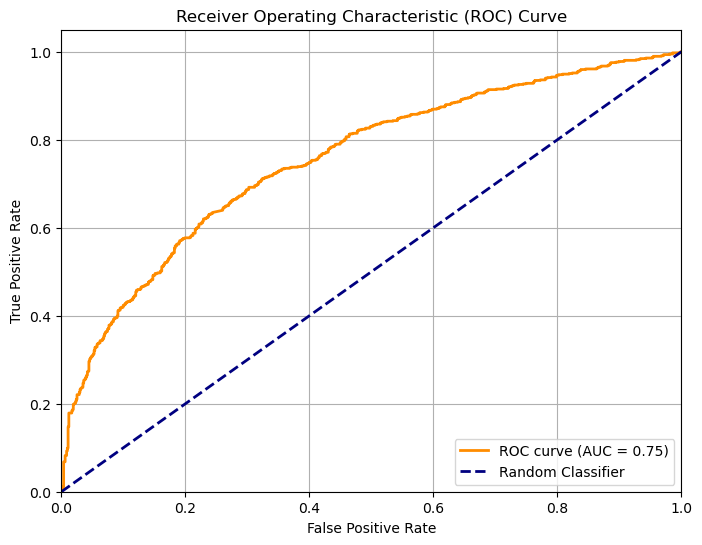

```
AUC Score: 0.754
Interpretation: Fair
```

```python
svm_2 = SVC(probability=True, C=1, gamma='auto', kernel='rbf')

svm_2.fit(X_train_scaled, y_training)

y_prob = svm_2.predict_proba(X_test_scaled)[:, 1]

fpr, tpr, thresholds = roc_curve(y_test, y_prob)

auc_score = roc_auc_score(y_test, y_prob)

plt.figure(figsize=(8, 6))
plt.plot(fpr, tpr, color='darkorange', lw=2, label=f'ROC curve (AUC = {auc_score:.2f})')
plt.plot([0, 1], [0, 1], color='navy', lw=2, linestyle='--', label='Random Classifier')
plt.xlim([0.0, 1.0])
plt.ylim([0.0, 1.05])
plt.xlabel('False Positive Rate')
plt.ylabel('True Positive Rate')
plt.title('Receiver Operating Characteristic (ROC) Curve')
plt.legend(loc="lower right")
plt.grid(True)
plt.show()

print(f"AUC Score: {auc_score:.3f}")

if auc_score >= 0.9:
    interpretation = "Excellent"
elif auc_score >= 0.8:
    interpretation = "Good"
elif auc_score >= 0.7:
    interpretation = "Fair"
else:
    interpretation = "Poor"

print(f"Interpretation: {interpretation}")
```

### Step 6.3: Error Analysis by Segments

Analyze where the model performs well and where it struggles:

- Create a dataframe combining test features, actual values, and predictions
- Add a column indicating whether the prediction was correct
- Calculate accuracy for different customer segments (e.g., by job type, age group, marital status)
- Identify segments where the model performs poorly
- Discuss potential reasons for lower performance in certain segments
- Suggest improvements based on this analysis

```python
results_df = pandas.DataFrame(X_test_scaled, columns=X_test.columns if hasattr(X_test, 'columns') else [f'feature_{i}' for i in range(X_test_scaled.shape[1])])
results_df['actual'] = y_test
results_df['predicted'] = svm_2.predict(X_test_scaled)
results_df['prediction_correct'] = results_df['actual'] == results_df['predicted']

overall_accuracy = accuracy_score(y_test, results_df['predicted'])
print(f"Overall Accuracy: {overall_accuracy:.3f}")
```

```
Overall Accuracy: 0.699
```

## 7. Modeling - Part 2: Support Vector Regression

### Objective

Build a Support Vector Regression model to predict a customer's current_balance.

### Step 7.1: Prepare Data for Regression

Set up the regression task:

- Create X (features) by dropping 'current_balance' (target), 'made_deposit' (classification target), and any engineered features you won't use
- Create y (target) as the 'current_balance' column
- Display summary statistics of the target variable
- Create visualizations (histogram and boxplot) to understand the distribution of current_balance
- Note any skewness or outliers in the target variable

```
count     8000.000000
mean      1516.520500
std       3168.517624
min      -3058.000000
25%        120.000000
50%        545.500000
75%       1694.000000
max      81204.000000
Name: current_balance, dtype: float64
```

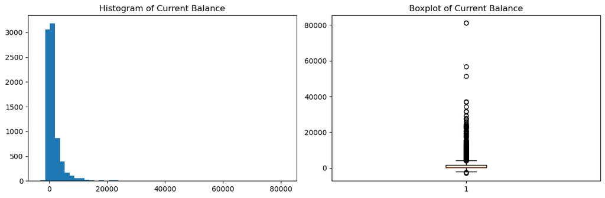

```python
df = pandas.read_csv("bank-tr.csv")

X = df.drop(columns=["current_balance", "made_deposit"])

y = df["current_balance"]

print(y.describe())

plt.figure(figsize=(12, 4))

plt.subplot(1, 2, 1)
plt.hist(y, bins=50)
plt.title('Histogram of Current Balance')

plt.subplot(1, 2, 2)
plt.boxplot(y)
plt.title('Boxplot of Current Balance')

plt.tight_layout()
plt.show()
```

### Step 7.2: Encode Categorical Variables

Encode categorical features for regression:

- Identify categorical and numerical columns
- Apply LabelEncoder to each categorical column
- Store encoders for potential future use
- Verify all columns are now numerical

```python
cat_columns = X.select_dtypes(include=['object']).columns
num_columns = X.select_dtypes(include=[np.number]).columns

label_encoders = {}
for col in cat_columns:
    le = LabelEncoder()
    X[col] = le.fit_transform(X[col])
    label_encoders[col] = le

print("Column types after encoding:")
print(X.dtypes)
```

```
Column types after encoding:
accountID                  int64
town                       int32
country                    int32
age                        int64
job                        int32
marital                    int32
education                  int32
defaulted?                 int32
housing                    int32
has_loan                   int32
last_contact               int32
cc_tr                      int64
last_contact_day           int64
last_contact_month         int32
campaign                   int64
days_since_last_contact    int64
previous                   int64
poutcome                   int32
dtype: object
```

### Step 7.3: Split Data for Regression

Create train, validation, and test sets:

- Use the same 60-20-20 split strategy as in classification
- First split: 80% (train+val) and 20% test
- Second split: 75% train and 25% validation from the 80%
- Use random_state=42 for reproducibility
- Print the sizes of each set

```python
X_temp, X_test, y_temp, y_test = train_test_split(X, y, test_size=0.2, random_state=42)
X_training, X_val, y_training, y_val = train_test_split(X_temp, y_temp, test_size=0.25, random_state=42)

print(f"Training set size: {X_training.shape[0]}")
print(f"Validation set size: {X_val.shape[0]}")
print(f"Test set size: {X_test.shape[0]}")
```

```
Training set size: 4800
Validation set size: 1600
Test set size: 1600
```

### Step 7.4: Feature Scaling for Regression

Scale both features and target variable:

- Initialize two StandardScalers: one for features (X) and one for target (y)
- Fit the feature scaler on training features and transform all three sets
- Fit the target scaler on training target and transform all three target sets
- Note: Scaling the target helps SVR performance, but remember to inverse transform predictions
- Verify the scaling was applied correctly

```python
scaler_X = StandardScaler()
scaler_y = StandardScaler()

X_training_scaled = scaler_X.fit_transform(X_training)
X_val_scaled = scaler_X.transform(X_val)
X_test_scaled = scaler_X.transform(X_test)

y_training_scaled = scaler_y.fit_transform(y_training.values.reshape(-1, 1)).ravel()
y_val_scaled = scaler_y.transform(y_val.values.reshape(-1, 1)).ravel()
y_test_scaled = scaler_y.transform(y_test.values.reshape(-1, 1)).ravel()

print("Training set mean (features):", X_training_scaled.mean(axis=0))
print("Training set std (features):", X_training_scaled.std(axis=0))
print("Training set mean (target):", y_training_scaled.mean())
print("Training set std (target):", y_training_scaled.std())
```

```
Training set mean (features): [ 1.36927506e-16  8.34517640e-17  1.42404607e-15  1.05101113e-16
  6.95739762e-17 -4.81096644e-17  8.88178420e-18 -1.46179365e-17
 -9.62193288e-17 -2.25375274e-16  7.10542736e-17  3.10862447e-17
 -9.17784367e-17 -5.25505565e-17  5.32907052e-17  1.77635684e-17
  0.00000000e+00  2.02800739e-16]
Training set std (features): [1. 1. 1. 1. 1. 1. 1. 1. 1. 1. 1. 1. 1. 1. 1. 1. 1. 1.]
Training set mean (target): -4.4408920985006264e-17
Training set std (target): 1.0
```

### Step 7.5: Build Baseline SVR Model

Create a baseline Support Vector Regression model:

- Initialize an SVR with default parameters and RBF kernel
- Train on the scaled training data
- Make predictions on the validation set (remember these are scaled)
- Inverse transform the predictions to get them back to original scale
- Calculate and display:
  - RMSE (Root Mean Squared Error)
  - MAE (Mean Absolute Error)
  - R² Score (coefficient of determination)
- Interpret these metrics in the context of the problem

```python
svr_baseline = SVR(kernel='rbf')
svr_baseline.fit(X_training_scaled, y_training_scaled)

y_val_pred_scaled = svr_baseline.predict(X_val_scaled)
y_val_pred = scaler_y.inverse_transform(y_val_pred_scaled.reshape(-1, 1)).ravel()

rmse = np.sqrt(mean_squared_error(y_val, y_val_pred))
mae = mean_absolute_error(y_val, y_val_pred)
r2 = r2_score(y_val, y_val_pred)

print(f"RMSE: {rmse:.2f}")
print(f"MAE: {mae:.2f}")
print(f"R² Score: {r2:.2f}")
```

```
RMSE: 3217.07
MAE: 1436.83
R² Score: -0.04
```

### Step 7.6: Hyperparameter Tuning for SVR

Find optimal hyperparameters using GridSearchCV:

- Define a parameter grid with:
  - **C**: Regularization (try 0.1, 1, 10, 100)
  - **gamma**: Kernel coefficient (try 'scale', 'auto', 0.001, 0.01)
  - **epsilon**: Epsilon-tube (try 0.01, 0.1, 0.2)
  - **kernel**: Kernel type (try 'rbf', 'linear')
- Use GridSearchCV with 5-fold cross-validation
- Use 'neg_mean_squared_error' as the scoring metric
- Fit on the scaled training data
- Display the best parameters and best score
- Note: This may take several minutes

```python
param_grid = {
    'C': [0.1, 1, 10, 100],
    'gamma': ['scale', 'auto', 0.001, 0.01],
    'epsilon': [0.01, 0.1, 0.2],
    'kernel': ['rbf', 'linear']
}

gs_1 = GridSearchCV(SVR(), param_grid, cv=5, scoring='neg_mean_squared_error', n_jobs=-1, refit=True)
gs_1.fit(X_training_scaled, y_training_scaled)

print("Best parameters:", gs_1.best_params_)
print("Best score:", -gs_1.best_score_)
```

```
Best parameters: {'C': 1, 'epsilon': 0.2, 'gamma': 'auto', 'kernel': 'rbf'}
Best score: 1.0062605044467057
```

### Step 7.7: Train Final SVR Model

Evaluate the tuned SVR model:

- Extract the best estimator from grid search
- Make predictions on the validation set
- Inverse transform predictions to original scale
- Calculate RMSE, MAE, and R² score
- Compare with the baseline model
- Report the improvement achieved through tuning

```python
y_val_pred_tuned_scaled = gs_1.predict(X_val_scaled)
y_val_pred_tuned = scaler_y.inverse_transform(y_val_pred_tuned_scaled.reshape(-1, 1)).ravel()

rmse_tuned = np.sqrt(mean_squared_error(y_val, y_val_pred_tuned))
mae_tuned = mean_absolute_error(y_val, y_val_pred_tuned)
r2_tuned = r2_score(y_val, y_val_pred_tuned)

print(f"Tuned Model - RMSE: {rmse_tuned:.2f}, MAE: {mae_tuned:.2f}, R²: {r2_tuned:.2f}")
print(f"Baseline Model - RMSE: {rmse:.2f}, MAE: {mae:.2f}, R²: {r2:.2f}")
print(f"RMSE Improvement: {rmse - rmse_tuned:.2f}")
print(f"R² Improvement: {r2_tuned - r2:.2f}")
```

```
Tuned Model - RMSE: 3183.83, MAE: 1459.15, R²: -0.02
Baseline Model - RMSE: 3217.07, MAE: 1436.83, R²: -0.04
RMSE Improvement: 33.24
R² Improvement: 0.02
```

### Step 7.8: Final SVR Evaluation on Test Set

Evaluate the final SVR model on unseen test data:

- Use the best model to predict on the test set
- Inverse transform predictions
- Calculate and display final test metrics (RMSE, MAE, R²)
- Compare test performance with validation performance
- Report the mean and standard deviation of the target variable for context

```python
y_test_pred_scaled = gs_1.predict(X_test_scaled)
y_test_pred = scaler_y.inverse_transform(y_test_pred_scaled.reshape(-1, 1)).ravel()

rmse_test = np.sqrt(mean_squared_error(y_test, y_test_pred))
mae_test = mean_absolute_error(y_test, y_test_pred)
r2_test = r2_score(y_test, y_test_pred)

print(f"Test Set - RMSE: {rmse_test:.2f}, MAE: {mae_test:.2f}, R²: {r2_test:.2f}")
print(f"Validation Set - RMSE: {rmse_tuned:.2f}, MAE: {mae_tuned:.2f}, R²: {r2_tuned:.2f}")
print(f"Target Variable - Mean: {y.mean():.2f}, Std: {y.std():.2f}")
```

```
Test Set - RMSE: 3155.70, MAE: 1442.19, R²: -0.03
Validation Set - RMSE: 3183.83, MAE: 1459.15, R²: -0.02
Target Variable - Mean: 1516.52, Std: 3168.52
```

## 8. Evaluation - Regression

### Step 8.1: Predicted vs Actual Values

Visualize model predictions:

- Create a scatter plot with actual values on x-axis and predicted values on y-axis
- Add a diagonal reference line representing perfect predictions
- Format the plot with proper labels and title
- Interpret the plot:
  - Points close to the line indicate good predictions
  - Systematic deviations suggest bias
  - Spread around the line indicates variance in predictions

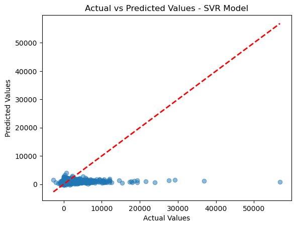

```
Interpretation: Points close to the red diagonal line indicate accurate predictions.
Systematic deviations from the line would suggest model bias.
The spread of points around the line shows the variance in prediction accuracy.
```

```python
plt.scatter(y_test, y_test_pred, alpha=0.5)
plt.plot([y_test.min(), y_test.max()], [y_test.min(), y_test.max()], 'r--', linewidth=2)
plt.xlabel('Actual Values')
plt.ylabel('Predicted Values')
plt.title('Actual vs Predicted Values - SVR Model')
plt.show()

print("Interpretation: Points close to the red diagonal line indicate accurate predictions.")
print("Systematic deviations from the line would suggest model bias.")
print("The spread of points around the line shows the variance in prediction accuracy.")
```

### Step 8.2: Residual Analysis

Analyze prediction errors:

- Calculate residuals (actual - predicted)
- Create two plots:
  1. Residual plot: residuals vs predicted values
  2. Histogram of residuals
- Check for patterns in the residual plot:
  - Random scatter is good (homoscedasticity)
  - Patterns suggest model is missing something
  - Funnel shape suggests heteroscedasticity
- Check if residuals are normally distributed (from histogram)
- Calculate and display residual statistics (mean, std, min, max)
- Ideally, mean should be close to 0

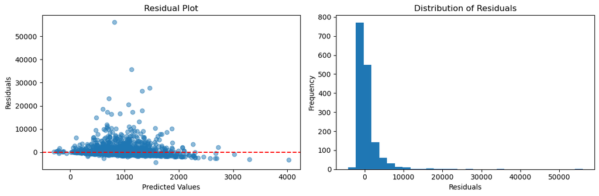

[output not shown]

```python
residuals = y_test - y_test_pred

plt.figure(figsize=(12, 4))

plt.subplot(1, 2, 1)
plt.scatter(y_test_pred, residuals, alpha=0.5)
plt.axhline(y=0, color='r', linestyle='--')
plt.xlabel('Predicted Values')
plt.ylabel('Residuals')
plt.title('Residual Plot')

plt.subplot(1, 2, 2)
plt.hist(residuals, bins=30)
plt.xlabel('Residuals')
plt.ylabel('Frequency')
plt.title('Distribution of Residuals')

plt.tight_layout()
plt.show()

print(f"Residual Statistics - Mean: {residuals.mean():.2f}, Std: {residuals.std():.2f}")
print(f"Min: {residuals.min():.2f}, Max: {residuals.max():.2f}")
print("Residual plot shows", "random scatter" if abs(residuals.mean()) < 0.1 else "systematic patterns")
print("Residual distribution is", "approximately normal" if abs(residuals.mean()) < residuals.std()/2 else "skewed")
```

## 9. Summary and Conclusions

### Step 9.1: Comprehensive Performance Summary

Create a comprehensive summary of both models:

- Summarize classification results:
  - Best hyperparameters found
  - Test accuracy
  - AUC score
  - Confusion matrix breakdown
- Summarize regression results:
  - Best hyperparameters found
  - Test RMSE, MAE, R²
  - Typical prediction error
- Compare both models' performance relative to baselines

### Step 9.2: Business Insights and Recommendations

Write a text analysis covering:

**Key Findings:**

- What did you learn about customer behavior from the classification model?
- What factors seem most important for predicting deposits?
- How accurate is the balance prediction from regression?

**Business Recommendations:**

- How should StirBank use the classification model?
- Which customers should they prioritize for marketing calls?
- What is the cost-benefit trade-off between false positives and false negatives?
- Should they consider different strategies for different customer segments?

**Model Limitations:**

- Where do the models perform poorly?
- What assumptions might not hold in practice?
- How might model performance degrade over time?

When there are new customers, the company should use models to predict whether the new guests will continue to use the company's services. They should make different sales and promotion strategies based on different types of customers. For custormers which has more housing loan and higher current balance, company should consider them more.

The location of the bank should also be a factor. As time goes by, the model may learn more unclean data, which can cause inaccuracy in its predictions and affect the company's adjustment of its strategies.

## Reflection Questions

Answer the following questions based on your work:

1. **Kernel Selection:** How does the RBF kernel differ from the linear kernel? When might you prefer one over the other?

Linear kernel generate a linear clasfication and RBF kernel reflect the data to a high demensional space(infinite demensional space). When data is linear seperated, linear kernel will be more preferred, and when data has complex distribution, RBF kernel may perform better.

2. **Hyperparameter C:** What is the role of the C parameter in SVM? What happens when C is very large? Very small?

C controls the balance of the performace of the model and how simple the model is. Overfitting when C is very large. And underfitting when C is very small.

3. **Feature Scaling:** Why is feature scaling critical for SVM? What would happen if you forgot to scale?

With different range, model may misunderstand the importance of different features.

4. **Error Trade-offs:** In the classification task, which is worse for the bank: false positives or false negatives? Why?

Fasle positives. Because if they find someone which doesn't want to use the service of the bank, customers may feel angry and this will demage the social evaluation.

5. **Model Improvements:** Based on your analysis, what are three specific ways you could improve these models?

Parameter tuning, feature scaling and data cleaning.

6. **CRISP-DM:** How did following the CRISP-DM framework help structure your analysis? What stages were most important?

It ensure that I follow the most efficient way and could train a good model from data. I think the stage of data preparing is the most important.

7. **Practical Deployment:** What challenges might arise when deploying these models in production at StirBank?

Stirbank may doesn't have some technical stuffs for IT, so they may meet some problems about the enviroment when install our ML system, for example the version of Python and sklearn, or the version of operating system.

**End of Lab 07**

### Submission Checklist:

- ✅ All code cells executed without errors
- ✅ All visualizations displayed correctly
- ✅ Results interpreted and explained
- ✅ Reflection questions answered
- ✅ Business recommendations provided
- ✅ Code is well-commented and readable